# Activity Type Prediction in Human Activity Recognition Data

Christian Bruun

Sunday, January 25, 2015

In this document we analyze exercise data from the Human Activity Recognition dataset, and attempt to fit a model that classifies the type of activity based on sensor data. We utilize a random forest method to fit a model, and achieve 97% accuracy in predicting activity type based on sensor data.

## Introduction

The data in this analysis is obtained from the Human Activity Recognition dataset. It consists of data obtained from movement sensors on several test subjects while they were performing one of 5 different activities. We wish to use the sensor data to predict what activity each subject was doing when the data was collected.

See the following page for information on the dataset itself: http://groupware.les.inf.puc-rio.br/har

## Data Loading

The data consists of two sets: a training set consisting of 19,622 observations, and a testing set consisting of 20 observations (this will not be used in this analysis). The data was accessed on January 25, 2015.

```r
## Load libraries to be used
library(caret)
library(randomForest)
```

```r
## Download data files
train_url <- "https://d396qusza40orc.cloudfront.net/predmachlearn/pml-training.csv"
if (!file.exists("pml-training.csv")) {
  download.file(train_url, destfile = "pml-training.csv", mode="wb")
  trainDateDownloaded <- date()
}

test_url <- "https://d396qusza40orc.cloudfront.net/predmachlearn/pml-testing.csv"
if (!file.exists("pml-testing.csv")) {
  download.file(test_url, destfile = "pml-testing.csv", mode="wb")
  testDateDownloaded <- date()
}

## Load data as data frame
## Set empty strings and "#DIV/0!" to NA
training <- read.csv("pml-training.csv", na.strings=c("","#DIV/0!"))
testing <- read.csv("pml-testing.csv", na.strings=c("","#DIV/0!"))
```

The training dataset contains 160 data columns, including 7 data columns identifying the trial number, subject name, and date of observation; 152 columns containing data from activity sensors, and the “classe” column identifying the activity type.

## Exploratory Analyses

For the purpose of this analysis, we will not consider trial number, user name, or date of observation as predictors in our model, so we remove these from the dataset.

```r
## Remove columns unrelated to model
## x, user_name, raw_timestamp_part_1, raw_timestamp_part_2, cvtd_timestamp,
## new_window, and num_window
training <- training[-c(1,2,3,4,5,6,7)]
testing <- testing[-c(1,2,3,4,5,6,7)]
```

A quick inspection of the data shows that there are several variables that have very low variability in the observations, and will probably not be useful as predictors. We remove these from the dataset.

```r
## Remove near zero var variables
nzVar <- nearZeroVar(training)
training <- training[-nzVar]
testing <- testing[-nzVar]
```

There are also several variables that contain only a small number of total observations (all have fewer than 500 observations in the training set), with all other data points as “NA”. These also are not useful for our model, so we remove them from the dataset. We will be using a random forest method in our predictive model, so this will also save us from having to impute the missing values in the dataset.

```r
## Find columns containing NA values and remove them also
na_vals <- which(apply(training, 2, function(x) sum(is.na(x)) > 0))
training <- training[-na_vals]
testing <- testing[-na_vals]
```

The resulting dataset has only 52 predictors from the sensor data columns and one column for the “classe” outcome variable. We also note that all of the sensor data columns are either of type “integer” or “numeric”, so we may treat these as numerics for the purpose of modeling.

A quick plot of activity type against each of the remaining variables shows that, while the observations are generally evenly distributed among each activity class, the observations in each sensor data are often split into two or more classes. Presumably, this indicates whether or not the sensor was actuated. For example, see the following plot:

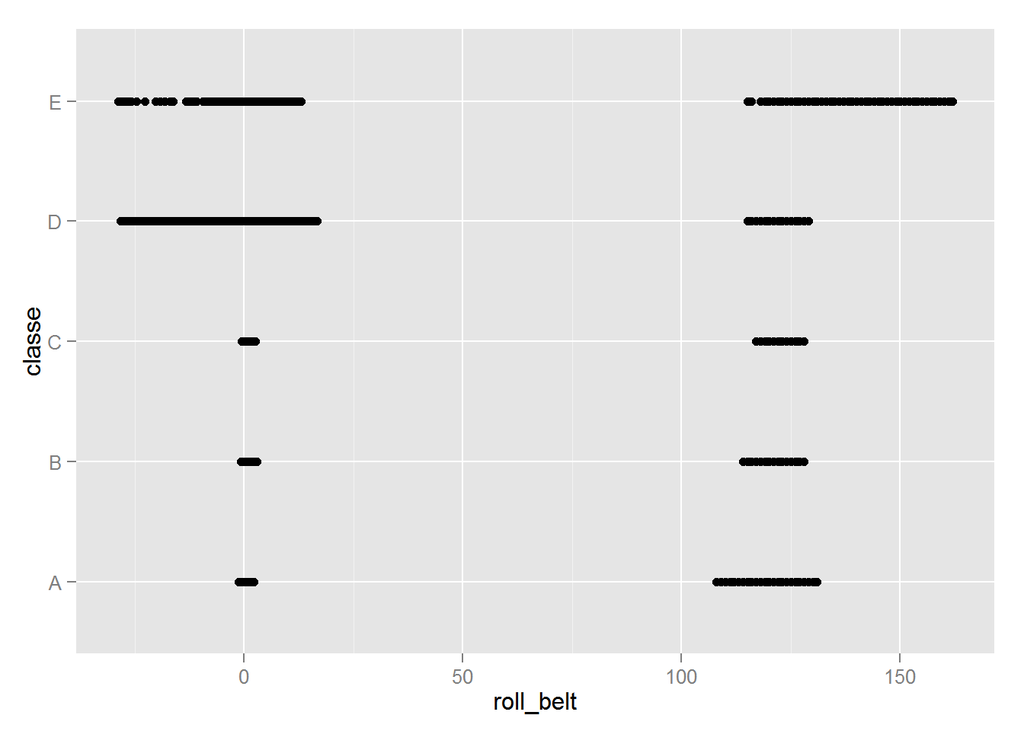

```r
qplot(roll_belt, classe, data=training)
```

This suggests that it may be useful to cluster the predictor variables into factor classes. This was not done for this model, but may be useful to investigate for future improvements to the model.

A comparison of the pairwise correlations between the remaining sensor variables shows there is a high correlation between many of the variables.

```r
M <- abs(cor(training[,-53]))
diag(M) <- 0
which(M > 0.8, arr.ind=T)
```

```
##                  row col
## yaw_belt           3   1
## total_accel_belt   4   1
## accel_belt_y       9   1
## accel_belt_z      10   1
## accel_belt_x       8   2
## magnet_belt_x     11   2
## roll_belt          1   3
## roll_belt          1   4
## accel_belt_y       9   4
## accel_belt_z      10   4
## pitch_belt         2   8
## magnet_belt_x     11   8
## roll_belt          1   9
## total_accel_belt   4   9
## accel_belt_z      10   9
## roll_belt          1  10
## total_accel_belt   4  10
## accel_belt_y       9  10
## pitch_belt         2  11
## accel_belt_x       8  11
## gyros_arm_y       19  18
## gyros_arm_x       18  19
## magnet_arm_x      24  21
## accel_arm_x       21  24
## magnet_arm_z      26  25
## magnet_arm_y      25  26
## accel_dumbbell_x  34  28
## accel_dumbbell_z  36  29
## gyros_dumbbell_z  33  31
## gyros_forearm_z   46  31
## gyros_dumbbell_x  31  33
## gyros_forearm_z   46  33
## pitch_dumbbell    28  34
## yaw_dumbbell      29  36
## gyros_forearm_z   46  45
## gyros_dumbbell_x  31  46
## gyros_dumbbell_z  33  46
## gyros_forearm_y   45  46
```

For this reason, we will want to use principal components to preprocess our model inputs and decrease the number of predictors.

## Model Selection

To fit our model, we first separate the training data into a training set and a verification set.

```r
## Separate into sample and outSample data sets for testing purposes
## Variable to be predicted is 'classe'
#set.seed(13552)
set.seed(1362)
inSampleFilter <- createDataPartition(y=training$classe, p=0.7, list=FALSE)
inSample <- training[inSampleFilter,]
outSample <- training[-inSampleFilter,]
```

We fit the model on the training set. Once we have a model, we validate it against the verification set.

As noted above, we use a random forest model. This was chosen because we would like to classify the activities into one of five types, and we do not know a priori any information that can tell us which predictors might be more useful in this classification.

```r
## Specify OOB resampling for randomForest
## and limit to 30 PCA components
fitControl <- trainControl(method="oob",
                           preProcOptions=c(pcaComp=30))

## Fit model using randomForest
## Preprocess with PCA
model <- train(classe ~ .,
               method="rf",
               data=inSample,
               preProcess=c("pca"),
               trControl=fitControl)
```

The resulting model reports an expected accuracy of 97.5%.

```r
model
```

```
## Random Forest
##
## 13737 samples
##    52 predictor
##     5 classes: 'A', 'B', 'C', 'D', 'E'
##
## Pre-processing: principal component signal extraction, scaled, centered
## Resampling results across tuning parameters:
##
##   mtry  Accuracy  Kappa
##    2    0.9752    0.9686
##   27    0.9684    0.9600
##   52    0.9680    0.9595
##
## Accuracy was used to select the optimal model using  the largest value.
## The final value used for the model was mtry = 2.
```

## Model Analyses

We can apply our model results to the testing and verification data to check the accuracy estimate.

```r
pred1 <- predict(model, inSample)
pred2 <- predict(model, outSample)

sum(pred1 == inSample$classe) / nrow(inSample)
```

```
## [1] 1
```

```r
sum(pred2 == outSample$classe) / nrow(outSample)
```

```
## [1] 0.9776
```